# Fraud Detection with Machine Learning

# **-Fraud detection**

**Classification task**: we want to forecast if a transaction is fraudulent (column isFraud)

# **-Loading Libraries**

The first step consists of loading the packages in order to manipulate and work on the data

```r
library(tidyverse)          # for data manipulation
library(data.table)         # To import csv sheets rapidly
library(fastDummies)        # For dummies
library(RhpcBLASctl)        # For multi-threading
library(dplyr)              #for data manipulation
library(ggplot2)            # For the plots
library(gridExtra)          #to arrange 2 graphs in one row
library(R.utils)            #to read gz files directly
library(scales)             # for % in density plots
library(ggrepel)            # for graph repel (labels)
library(naniar)             # for graph repel (labels)
library(corrplot)           # for correlation matrix visualization
library(caret)              # for machine learning models
library(pROC)               # for ROC and AUC curves
library(xgboost)            # for XGBoost machine learning model
library(lightgbm)           # for LightGBM gradient boosting model
library(smotefamily)        # library for SMOTE
library(superml)            # for feature engineering and preprocessing
library(SHAPforxgboost)     # for SHAP values with XGBoost
library(DALEX)              # for explainable AI and model interpretation
```

# **-Understanding the dataset**

Now that the libraries have been imported we can start exploring the dataset

```r
load("fraud_detection.RData") #loading the RData file
fraud <- transactions     # and assigning it to a variable Fraud
rm(transactions)        # now that fraud is assigned, remove transactions to save memory
```

```r
dim(fraud) #analyzing the dimensions of the dataset, in our case, the dataset has 590540 rows and 393 columns which is quite big.
```

```
[1] 590540    393
```

To start is fundamental to highlight that `isFraud` is our target variable since we are performing a binary classification task and we want to forecast if a transaction is fraudolent or not.

```r
head(fraud) #We can see here the first 6 rows of the dataset
```

| isFraud | TransactionDT | TransactionAmt | ProductCD | card1 | card2 | card3 | card4 | card5 | card6 | addr1 | addr2 | dist1 | dist2 | P_emaildomain | R_emaildomain | C1 | C2 | C3 | C4 | C5 | C6 | C7 | C8 | C9 | C10 | C11 | C12 | C13 | C14 | … |
| --- | --- | --- | --- | --- | --- | --- | --- | --- | --- | --- | --- | --- | --- | --- | --- | --- | --- | --- | --- | --- | --- | --- | --- | --- | --- | --- | --- | --- | --- | --- |
| 0 | 86400 | 68.5 | W | 13926 | NA | 150 | discover | 142 | credit | 315 | 87 | 19 | NA | NA | NA | 1 | 1 | 0 | 0 | 0 | 1 | 0 | 0 | 1 | 0 | 2 | 0 | 1 | 1 | … |
| 0 | 86401 | 29.0 | W | 2755 | 404 | 150 | mastercard | 102 | credit | 325 | 87 | NA | NA | gmail.com | NA | 1 | 1 | 0 | 0 | 0 | 1 | 0 | 0 | 0 | 0 | 1 | 0 | 1 | 1 | … |
| 0 | 86469 | 59.0 | W | 4663 | 490 | 150 | visa | 166 | debit | 330 | 87 | 287 | NA | outlook.com | NA | 1 | 1 | 0 | 0 | 0 | 1 | 0 | 0 | 1 | 0 | 1 | 0 | 1 | 1 | … |
| 0 | 86499 | 50.0 | W | 18132 | 567 | 150 | mastercard | 117 | debit | 476 | 87 | NA | NA | yahoo.com | NA | 2 | 5 | 0 | 0 | 0 | 4 | 0 | 0 | 1 | 0 | 1 | 0 | 25 | 1 | … |
| 0 | 86506 | 50.0 | H | 4497 | 514 | 150 | mastercard | 102 | credit | 420 | 87 | NA | NA | gmail.com | NA | 1 | 1 | 0 | 0 | 0 | 1 | 0 | 1 | 0 | 1 | 1 | 0 | 1 | 1 | … |
| 0 | 86510 | 49.0 | W | 5937 | 555 | 150 | visa | 226 | debit | 272 | 87 | 36 | NA | gmail.com | NA | 1 | 1 | 0 | 0 | 0 | 1 | 0 | 0 | 1 | 0 | 1 | 0 | 1 | 1 | … |

```r
tail(fraud) #we can see here the last 6 rows of the dataset
```

| isFraud | TransactionDT | TransactionAmt | ProductCD | card1 | card2 | card3 | card4 | card5 | card6 | addr1 | addr2 | dist1 | dist2 | P_emaildomain | R_emaildomain | C1 | C2 | C3 | C4 | C5 | C6 | C7 | C8 | C9 | C10 | C11 | C12 | C13 | C14 | … |
| --- | --- | --- | --- | --- | --- | --- | --- | --- | --- | --- | --- | --- | --- | --- | --- | --- | --- | --- | --- | --- | --- | --- | --- | --- | --- | --- | --- | --- | --- | --- |
| 0 | 15811030 | 67.505 | C | 5812 | 408 | 185 | mastercard | 224 | debit | NA | NA | NA | NA | gmail.com | gmail.com | 1 | 1 | 0 | 1 | 0 | 1 | 1 | 1 | 0 | 0 | 1 | 1 | 1 | 1 | … |
| 0 | 15811047 | 49.000 | W | 6550 | NA | 150 | visa | 226 | debit | 272 | 87 | 48 | NA | NA | NA | 2 | 1 | 0 | 0 | 1 | 0 | 0 | 0 | 2 | 0 | 1 | 0 | 3 | 2 | … |
| 0 | 15811049 | 39.500 | W | 10444 | 225 | 150 | mastercard | 224 | debit | 204 | 87 | NA | NA | gmail.com | NA | 1 | 1 | 0 | 0 | 0 | 1 | 0 | 0 | 1 | 0 | 1 | 0 | 1 | 1 | … |
| 0 | 15811079 | 30.950 | W | 12037 | 595 | 150 | mastercard | 224 | debit | 231 | 87 | NA | NA | gmail.com | NA | 1 | 1 | 0 | 0 | 1 | 1 | 0 | 0 | 1 | 0 | 1 | 0 | 1 | 1 | … |
| 0 | 15811088 | 117.000 | W | 7826 | 481 | 150 | mastercard | 224 | debit | 387 | 87 | 3 | NA | aol.com | NA | 1 | 1 | 0 | 0 | 0 | 3 | 0 | 0 | 2 | 0 | 1 | 1 | 5 | 1 | … |
| 0 | 15811131 | 279.950 | W | 15066 | 170 | 150 | mastercard | 102 | credit | 299 | 87 | NA | NA | gmail.com | NA | 2 | 1 | 0 | 0 | 1 | 1 | 0 | 0 | 2 | 0 | 1 | 0 | 1 | 1 | … |

```r
print(min(fraud$TransactionDT))
```

```
[1] 86400
```

```r
print(max(fraud$TransactionDT))
```

```
[1] 15811131
```

# -Transaction Data Structure

**Transaction Details**

- `TransactionDT`: Time elapsed from a reference point (not actual timestamp)
- `TransactionAMT`: Payment value in USD
- `ProductCD`: Unique code identifying the transaction’s product

**Payment Information**

- `card1` through `card6`: Details about the payment card including:
  - Card type and category
  - Issuing bank
  - Country of issue
  - Other card-specific attributes

**Location & Contact Data**

- `addr` fields: Address information
- `dist`: Distance measurements
- `P_emaildomain`: Email domain of the purchaser
- `R_emaildomain`: Email domain of the recipient

**Analytics & Metrics**

- `C1-C14`: Various counting metrics (e.g., number of addresses linked to a card)
- `D1-D15`: Time-based measurements between events
- `M1-M9`: Matching indicators (e.g., verification of name matching between card and address)
- `Vxxx`: Advanced features engineered by Vesta, including:
  - Rankings
  - Counts
  - Relationship mappings between entities

**Categorical Variables**

- Product code (`ProductCD`)
- All card-related fields (`card1-card6`)
- Address fields (`addr1, addr2`)
- Email domains (purchaser and recipient)
- Match indicators (`M1-M9`)

**Identity Information**

**Overview**

This dataset contains digital fingerprinting and network data collected through Vesta’s fraud prevention system and their security partners. Field names are anonymized due to privacy and contractual requirements.

**Key Components**

- Network connection data:
  - IP addresses
  - Internet Service Provider information
  - Proxy details
- Digital signatures:
  - Browser details
  - Operating system information
  - Version data

**Categorical Fields**

- Device type classification
- Device information
- Identity fields (`id12` through `id38`)

```r
str(fraud)       # Understand the structure
```

```
tibble [590,540 × 393] (S3: tbl_df/tbl/data.frame)
 $ isFraud       : num [1:590540] 0 0 0 0 0 0 0 0 0 0 ...
 $ TransactionDT : num [1:590540] 86400 86401 86469 86499 86506 ...
 $ TransactionAmt: num [1:590540] 68.5 29 59 50 50 ...
 $ ProductCD     : chr [1:590540] "W" "W" "W" "W" ...
 $ card1         : num [1:590540] 13926 2755 4663 18132 4497 ...
 $ card2         : num [1:590540] NA 404 490 567 514 555 360 490 100 111 ...
 $ card3         : num [1:590540] 150 150 150 150 150 150 150 150 150 150 ...
 $ card4         : chr [1:590540] "discover" "mastercard" "visa" "mastercard" ...
 $ card5         : num [1:590540] 142 102 166 117 102 226 166 226 226 224 ...
 $ card6         : chr [1:590540] "credit" "credit" "debit" "debit" ...
 $ addr1         : num [1:590540] 315 325 330 476 420 272 126 325 337 204 ...
 $ addr2         : num [1:590540] 87 87 87 87 87 87 87 87 87 87 ...
 $ dist1         : num [1:590540] 19 NA 287 NA NA 36 0 NA NA 19 ...
 $ dist2         : num [1:590540] NA NA NA NA NA NA NA NA NA NA ...
```

[output cut: 86 more lines]

```r
summary(fraud)   # Summary statistics
```

```
    isFraud        TransactionDT      TransactionAmt      ProductCD
 Min.   :0.00000   Min.   :   86400   Min.   :    0.25   Length:590540
 1st Qu.:0.00000   1st Qu.: 3027058   1st Qu.:   43.32   Class :character
 Median :0.00000   Median : 7306528   Median :   68.77   Mode  :character
 Mean   :0.03499   Mean   : 7372311   Mean   :  135.03
 3rd Qu.:0.00000   3rd Qu.:11246620   3rd Qu.:  125.00
 Max.   :1.00000   Max.   :15811131   Max.   :31937.39

     card1           card2           card3          card4
 Min.   : 1000   Min.   :100.0   Min.   :100.0   Length:590540
 1st Qu.: 6019   1st Qu.:214.0   1st Qu.:150.0   Class :character
 Median : 9678   Median :361.0   Median :150.0   Mode  :character
 Mean   : 9899   Mean   :362.6   Mean   :153.2
 3rd Qu.:14184   3rd Qu.:512.0   3rd Qu.:150.0
 Max.   :18396   Max.   :600.0   Max.   :231.0
                 NA's   :8933    NA's   :1565
     card5          card6               addr1           addr2
 Min.   :100.0   Length:590540      Min.   :100.0   Min.   : 10.0
 1st Qu.:166.0   Class :character   1st Qu.:204.0   1st Qu.: 87.0
 Median :226.0   Mode  :character   Median :299.0   Median : 87.0
 Mean   :199.3                      Mean   :290.7   Mean   : 86.8
 3rd Qu.:226.0                      3rd Qu.:330.0   3rd Qu.: 87.0
 Max.   :237.0                      Max.   :540.0   Max.   :102.0
 NA's   :4259                       NA's   :65706   NA's   :65706
     dist1             dist2         P_emaildomain      R_emaildomain
 Min.   :    0.0   Min.   :    0.0   Length:590540      Length:590540
 1st Qu.:    3.0   1st Qu.:    7.0   Class :character   Class :character
 Median :    8.0   Median :   37.0   Mode  :character   Mode  :character
 Mean   :  118.5   Mean   :  231.9
 3rd Qu.:   24.0   3rd Qu.:  206.0
 Max.   :10286.0   Max.   :11623.0
 NA's   :352271    NA's   :552913
       C1                C2                C3                  C4
 Min.   :   0.00   Min.   :   0.00   Min.   : 0.000000   Min.   :   0.000
 1st Qu.:   1.00   1st Qu.:   1.00   1st Qu.: 0.000000   1st Qu.:   0.000
 Median :   1.00   Median :   1.00   Median : 0.000000   Median :   0.000
 Mean   :  14.09   Mean   :  15.27   Mean   : 0.005644   Mean   :   4.092
 3rd Qu.:   3.00   3rd Qu.:   3.00   3rd Qu.: 0.000000   3rd Qu.:   0.000
 Max.   :4685.00   Max.   :5691.00   Max.   :26.000000   Max.   :2253.000

```

[output cut: 729 more lines]

```
 Min.   :     0   Min.   :     0   Min.   :    0.0   Min.   :    0.0
 1st Qu.:     0   1st Qu.:     0   1st Qu.:    0.0   1st Qu.:    0.0
 Median :     0   Median :     0   Median :    0.0   Median :    0.0
 Mean   :  1376   Mean   :  1015   Mean   :    9.8   Mean   :   59.2
 3rd Qu.:    25   3rd Qu.:     0   3rd Qu.:    0.0   3rd Qu.:    0.0
 Max.   :160000   Max.   :160000   Max.   :55125.0   Max.   :55125.0
 NA's   :508189   NA's   :508189   NA's   :508189    NA's   :508189
      V336              V337               V338               V339
 Min.   :    0.0   Min.   :     0.0   Min.   :     0.0   Min.   :     0.0
 1st Qu.:    0.0   1st Qu.:     0.0   1st Qu.:     0.0   1st Qu.:     0.0
 Median :    0.0   Median :     0.0   Median :     0.0   Median :     0.0
 Mean   :   28.5   Mean   :    55.4   Mean   :   151.2   Mean   :   100.7
 3rd Qu.:    0.0   3rd Qu.:     0.0   3rd Qu.:     0.0   3rd Qu.:     0.0
 Max.   :55125.0   Max.   :104060.0   Max.   :104060.0   Max.   :104060.0
 NA's   :508189    NA's   :508189     NA's   :508189     NA's   :508189
```

```r
sum(is.na(fraud)) #counting missing values
```

```
[1] 95566686
```

Now, after having analyzed the dataset and understood that it is not only quite huge to manage but also has a huge number of missing values, we need to reduce its dimensionality and remove the missing values.

```r
fraud <- fraud[, colMeans(is.na(fraud)) <= 0.5] # Remove columns with >50% missing
fraud <- na.omit(fraud) # Remove rows with any missing values
```

```r
set.seed(123) # For reproducibility
fraud_subset <- fraud[sample(nrow(fraud), 50000), ]
```

```r
save(fraud_subset, file = "fraud_subset.RData")
```

Now, we are going to work on the new reduced dataset

```r
load("fraud_subset.RData") # Load the reduced dataset
new_fraud <- fraud_subset     # and assigning it to a variable new_fraud
rm(fraud_subset)        # now that new_fraud is assigned, remove fraud_subset to save memory
```

# **-Summary statistics of the reduced dataset**

```r
str(new_fraud)       # View the structure of the dataset
```

```
tibble [50,000 × 219] (S3: tbl_df/tbl/data.frame)
 $ isFraud       : num [1:50000] 0 0 0 0 0 0 0 0 0 0 ...
 $ TransactionDT : num [1:50000] 11625776 12779171 1198214 8188169 14497795 ...
 $ TransactionAmt: num [1:50000] 422 39 39 88 445 ...
 $ ProductCD     : chr [1:50000] "W" "W" "W" "W" ...
 $ card1         : num [1:50000] 18249 1906 8720 10486 7919 ...
 $ card2         : num [1:50000] 360 445 321 514 194 268 225 472 225 555 ...
 $ card3         : num [1:50000] 150 150 150 150 150 150 150 150 150 150 ...
 $ card4         : chr [1:50000] "mastercard" "mastercard" "visa" "mastercard" ...
 $ card5         : num [1:50000] 126 224 226 219 166 166 224 166 224 226 ...
 $ card6         : chr [1:50000] "debit" "debit" "debit" "credit" ...
 $ addr1         : num [1:50000] 177 325 110 231 325 325 123 310 204 299 ...
 $ addr2         : num [1:50000] 87 87 87 87 87 87 87 87 87 87 ...
 $ P_emaildomain : chr [1:50000] "yahoo.com" "gmail.com" "gmail.com" "anonymous.com" ...
 $ C1            : num [1:50000] 1 1 63 8 3 3 18 1 1 3 ...
```

[output cut: 88 more lines]

```r
dim(new_fraud)       # Check the dimensions (number of rows and columns)
```

```
[1] 50000   219
```

```r
summary(new_fraud)   # summary statistics of the reduced dataset
```

```
    isFraud        TransactionDT      TransactionAmt    ProductCD
 Min.   :0.00000   Min.   :   87149   Min.   :   2.0   Length:50000
 1st Qu.:0.00000   1st Qu.: 6056944   1st Qu.:  49.0   Class :character
 Median :0.00000   Median : 9490534   Median :  87.0   Mode  :character
 Mean   :0.03654   Mean   : 9102251   Mean   : 138.7
 3rd Qu.:0.00000   3rd Qu.:12691100   3rd Qu.: 157.0
 Max.   :1.00000   Max.   :15811088   Max.   :4191.0
     card1           card2           card3        card4
 Min.   : 1008   Min.   :100.0   Min.   :109   Length:50000
 1st Qu.: 6236   1st Qu.:215.0   1st Qu.:150   Class :character
 Median : 9537   Median :346.0   Median :150   Mode  :character
 Mean   : 9870   Mean   :354.2   Mean   :150
 3rd Qu.:13481   3rd Qu.:490.0   3rd Qu.:150
 Max.   :18384   Max.   :600.0   Max.   :231
     card5          card6               addr1         addr2
 Min.   :100.0   Length:50000       Min.   :104   Min.   :16
 1st Qu.:195.0   Class :character   1st Qu.:204   1st Qu.:87
 Median :226.0   Mode  :character   Median :299   Median :87
 Mean   :204.1                      Mean   :289   Mean   :87
 3rd Qu.:226.0                      3rd Qu.:330   3rd Qu.:87
 Max.   :235.0                      Max.   :536   Max.   :96
 P_emaildomain            C1                C2                C3          C4
 Length:50000       Min.   :  1.000   Min.   :  1.000   Min.   :0   Min.   :0
 Class :character   1st Qu.:  1.000   1st Qu.:  1.000   1st Qu.:0   1st Qu.:0
 Mode  :character   Median :  2.000   Median :  2.000   Median :0   Median :0
                    Mean   :  4.721   Mean   :  4.572   Mean   :0   Mean   :0
                    3rd Qu.:  3.000   3rd Qu.:  3.000   3rd Qu.:0   3rd Qu.:0
                    Max.   :337.000   Max.   :291.000   Max.   :0   Max.   :0
       C5               C6                C7          C8          C9
 Min.   :  0.00   Min.   :  1.000   Min.   :0   Min.   :0   Min.   :  1.000
 1st Qu.:  0.00   1st Qu.:  1.000   1st Qu.:0   1st Qu.:0   1st Qu.:  1.000
 Median :  0.00   Median :  1.000   Median :0   Median :0   Median :  1.000
 Mean   :  2.43   Mean   :  3.839   Mean   :0   Mean   :0   Mean   :  3.482
 3rd Qu.:  0.00   3rd Qu.:  2.000   3rd Qu.:0   3rd Qu.:0   3rd Qu.:  2.000
 Max.   :272.00   Max.   :324.000   Max.   :0   Max.   :0   Max.   :202.000
      C10         C11               C12              C13
 Min.   :0   Min.   :  1.000   Min.   :0.0000   Min.   :   0.00
 1st Qu.:0   1st Qu.:  1.000   1st Qu.:0.0000   1st Qu.:   3.00
 Median :0   Median :  1.000   Median :0.0000   Median :   7.00
 Mean   :0   Mean   :  3.402   Mean   :0.2482   Mean   :  24.06
```

[output cut: 288 more lines]

```
 Max.   :2061.000   Max.   :3489.5   Max.   :2228.00   Max.   :5565.0
      V315              V316               V317              V318
 Min.   :   0.00   Min.   :    0.00   Min.   :    0.0   Min.   :    0.00
 1st Qu.:   0.00   1st Qu.:    0.00   1st Qu.:    0.0   1st Qu.:    0.00
 Median :   0.00   Median :    0.00   Median :    0.0   Median :    0.00
 Mean   :  70.94   Mean   :   41.82   Mean   :  158.4   Mean   :   85.55
 3rd Qu.:  68.50   3rd Qu.:    0.00   3rd Qu.:    0.0   3rd Qu.:    0.00
 Max.   :3981.00   Max.   :16239.00   Max.   :25281.0   Max.   :17666.00
      V319              V320              V321
 Min.   :   0.00   Min.   :   0.00   Min.   :   0.0
 1st Qu.:   0.00   1st Qu.:   0.00   1st Qu.:   0.0
 Median :   0.00   Median :   0.00   Median :   0.0
 Mean   :  14.04   Mean   :  48.21   Mean   :  25.5
 3rd Qu.:   0.00   3rd Qu.:   0.00   3rd Qu.:   0.0
 Max.   :3384.00   Max.   :8275.00   Max.   :6880.0
```

```r
head(new_fraud)      # Preview the first few rows
```

| isFraud | TransactionDT | TransactionAmt | ProductCD | card1 | card2 | card3 | card4 | card5 | card6 | addr1 | addr2 | P_emaildomain | C1 | C2 | C3 | C4 | C5 | C6 | C7 | C8 | C9 | C10 | C11 | C12 | C13 | C14 | D1 | D2 | D3 | … |
| --- | --- | --- | --- | --- | --- | --- | --- | --- | --- | --- | --- | --- | --- | --- | --- | --- | --- | --- | --- | --- | --- | --- | --- | --- | --- | --- | --- | --- | --- | --- |
| 0 | 11625776 | 422.5 | W | 18249 | 360 | 150 | mastercard | 126 | debit | 177 | 87 | yahoo.com | 1 | 1 | 0 | 0 | 0 | 1 | 0 | 0 | 1 | 0 | 1 | 0 | 2 | 1 | 7 | 7 | 0 | … |
| 0 | 12779171 | 39.0 | W | 1906 | 445 | 150 | mastercard | 224 | debit | 325 | 87 | gmail.com | 1 | 4 | 0 | 0 | 0 | 3 | 0 | 0 | 1 | 0 | 1 | 1 | 17 | 1 | 108 | 108 | 0 | … |
| 0 | 1198214 | 39.0 | W | 8720 | 321 | 150 | visa | 226 | debit | 110 | 87 | gmail.com | 63 | 43 | 0 | 0 | 12 | 40 | 0 | 0 | 38 | 0 | 42 | 0 | 148 | 37 | 481 | 481 | 10 | … |
| 0 | 8188169 | 88.0 | W | 10486 | 514 | 150 | mastercard | 219 | credit | 231 | 87 | anonymous.com | 8 | 7 | 0 | 0 | 11 | 9 | 0 | 0 | 6 | 0 | 7 | 0 | 44 | 6 | 279 | 279 | 30 | … |
| 0 | 14497795 | 445.0 | W | 7919 | 194 | 150 | mastercard | 166 | debit | 325 | 87 | yahoo.com | 3 | 4 | 0 | 0 | 0 | 2 | 0 | 0 | 3 | 0 | 1 | 2 | 18 | 2 | 477 | 477 | 2 | … |
| 0 | 13486588 | 270.0 | W | 10856 | 268 | 150 | visa | 166 | debit | 325 | 87 | anonymous.com | 3 | 2 | 0 | 0 | 0 | 2 | 0 | 0 | 1 | 0 | 1 | 0 | 10 | 3 | 65 | 65 | 5 | … |

Now we have a new dataset with 50000 rows and 219 columns.

# **-Checking for missing values of the reduced dataset**

```r
# Count missing values in each column
colSums(is.na(new_fraud))
```

```
       isFraud  TransactionDT TransactionAmt      ProductCD          card1
             0              0              0              0              0
         card2          card3          card4          card5          card6
             0              0              0              0              0
         addr1          addr2  P_emaildomain             C1             C2
             0              0              0              0              0
            C3             C4             C5             C6             C7
             0              0              0              0              0
            C8             C9            C10            C11            C12
             0              0              0              0              0
           C13            C14             D1             D2             D3
             0              0              0              0              0
            D4            D10            D11            D15             M1
             0              0              0              0              0
            M2             M3             M4             M6             V1
             0              0              0              0              0
            V2             V3             V4             V5             V6
             0              0              0              0              0
            V7             V8             V9            V10            V11
             0              0              0              0              0
           V12            V13            V14            V15            V16
             0              0              0              0              0
           V17            V18            V19            V20            V21
             0              0              0              0              0
           V22            V23            V24            V25            V26
             0              0              0              0              0
           V27            V28            V29            V30            V31
             0              0              0              0              0
           V32            V33            V34            V35            V36
             0              0              0              0              0
           V37            V38            V39            V40            V41
             0              0              0              0              0
           V42            V43            V44            V45            V46
             0              0              0              0              0
           V47            V48            V49            V50            V51
             0              0              0              0              0
           V52            V53            V54            V55            V56
             0              0              0              0              0
           V57            V58            V59            V60            V61
             0              0              0              0              0
```

[output cut: 33 more lines]

```
             0              0              0              0              0
          V288           V289           V290           V291           V292
             0              0              0              0              0
          V293           V294           V295           V296           V297
             0              0              0              0              0
          V298           V299           V300           V301           V302
             0              0              0              0              0
          V303           V304           V305           V306           V307
             0              0              0              0              0
          V308           V309           V310           V311           V312
             0              0              0              0              0
          V313           V314           V315           V316           V317
             0              0              0              0              0
          V318           V319           V320           V321
             0              0              0              0
```

```r
# Percentage of missing values per column
colMeans(is.na(new_fraud)) * 100
```

```
       isFraud  TransactionDT TransactionAmt      ProductCD          card1
             0              0              0              0              0
         card2          card3          card4          card5          card6
             0              0              0              0              0
         addr1          addr2  P_emaildomain             C1             C2
             0              0              0              0              0
            C3             C4             C5             C6             C7
             0              0              0              0              0
            C8             C9            C10            C11            C12
             0              0              0              0              0
           C13            C14             D1             D2             D3
             0              0              0              0              0
            D4            D10            D11            D15             M1
             0              0              0              0              0
            M2             M3             M4             M6             V1
             0              0              0              0              0
            V2             V3             V4             V5             V6
             0              0              0              0              0
            V7             V8             V9            V10            V11
             0              0              0              0              0
           V12            V13            V14            V15            V16
             0              0              0              0              0
           V17            V18            V19            V20            V21
             0              0              0              0              0
           V22            V23            V24            V25            V26
             0              0              0              0              0
           V27            V28            V29            V30            V31
             0              0              0              0              0
           V32            V33            V34            V35            V36
             0              0              0              0              0
           V37            V38            V39            V40            V41
             0              0              0              0              0
           V42            V43            V44            V45            V46
             0              0              0              0              0
           V47            V48            V49            V50            V51
             0              0              0              0              0
           V52            V53            V54            V55            V56
             0              0              0              0              0
           V57            V58            V59            V60            V61
             0              0              0              0              0
```

[output cut: 33 more lines]

```
             0              0              0              0              0
          V288           V289           V290           V291           V292
             0              0              0              0              0
          V293           V294           V295           V296           V297
             0              0              0              0              0
          V298           V299           V300           V301           V302
             0              0              0              0              0
          V303           V304           V305           V306           V307
             0              0              0              0              0
          V308           V309           V310           V311           V312
             0              0              0              0              0
          V313           V314           V315           V316           V317
             0              0              0              0              0
          V318           V319           V320           V321
             0              0              0              0
```

We don’t have missing values in the new dataset

# **-Check for duplicates of the reduced dataset**

```r
# Check for duplicates
sum(duplicated(new_fraud))
```

```
[1] 0
```

```r
# Remove duplicates if any
new_fraud <- new_fraud[!duplicated(new_fraud),]
```

We do not have duplicates in the new dataset

# **-Column names in the new dataset**

```r
colnames(new_fraud) #checking the columns in the reduceded dataset
```

```
  [1] "isFraud"        "TransactionDT"  "TransactionAmt" "ProductCD"
  [5] "card1"          "card2"          "card3"          "card4"
  [9] "card5"          "card6"          "addr1"          "addr2"
 [13] "P_emaildomain"  "C1"             "C2"             "C3"
 [17] "C4"             "C5"             "C6"             "C7"
 [21] "C8"             "C9"             "C10"            "C11"
 [25] "C12"            "C13"            "C14"            "D1"
 [29] "D2"             "D3"             "D4"             "D10"
 [33] "D11"            "D15"            "M1"             "M2"
 [37] "M3"             "M4"             "M6"             "V1"
 [41] "V2"             "V3"             "V4"             "V5"
 [45] "V6"             "V7"             "V8"             "V9"
 [49] "V10"            "V11"            "V12"            "V13"
 [53] "V14"            "V15"            "V16"            "V17"
 [57] "V18"            "V19"            "V20"            "V21"
```

[output cut: 40 more lines]

# **-Check for the target variable (isFraud) distribution**

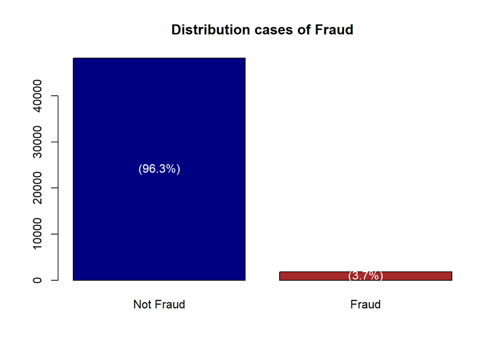

```r
# Create barplot with centered percentages
fraud_counts <- table(new_fraud$isFraud)
fraud_percentages <- prop.table(fraud_counts) * 100

bp <- barplot(fraud_counts,
        main="Distribution cases of Fraud",
        col=c("navy", "brown"),
        names.arg=c("Not Fraud", "Fraud"),
        yaxt="s")

# Add centered percentage labels
text(x=c(0.7, 1.9),
     y=fraud_counts/2,  # Dividing by 2 to center vertically
     labels=paste0("(", round(fraud_percentages, 1), "%)"),
     col=c("white", "white"))
```

**Observation:**

It is evident that our dataset is quite imbalanced, since we have over 96% of fraud detection recognized as Not Fraud and only 3% as Fraud. So we should improve our model!

# **-Check for the transaction Amount distribution**

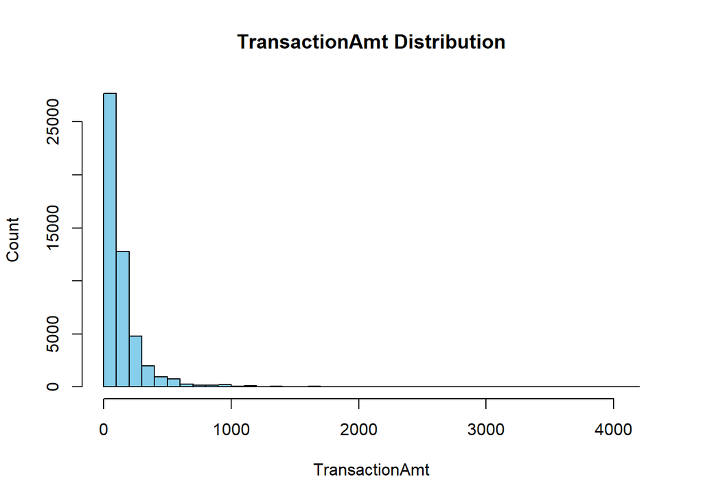

```r
# TransactionAmt Distribution
hist(new_fraud$TransactionAmt, main="TransactionAmt Distribution",
     xlab="TransactionAmt", ylab="Count", col="skyblue", breaks=50, freq=TRUE)
```

**Observations:**

1. **Right-Skewed Distribution**: most transactions have relatively small amounts, concentrated below **500 units**.
2. **Outliers** : a few transactions have significantly higher amounts, stretching beyond **4000 units**, indicating potential anomalies.

# **-Boxplot to detect outliers**

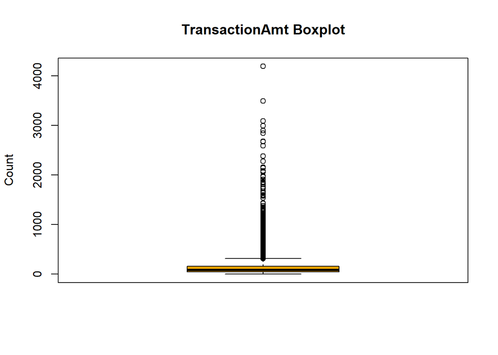

```r
# Boxplot to detect outliers
boxplot(new_fraud$TransactionAmt, main="TransactionAmt Boxplot", ylab = "Count", col="orange")
```

**Observations (Boxplot):**

- **Concentration of Values** : most transactions are tightly clustered near **low values**, indicating a **right-skewed distribution**.
- **Outliers**: numerous **outliers** are present, with transaction amounts exceeding **4000 units**, suggesting **potential anomalies** that may require **further analysis** or **transformation** to handle skewness effectively.

# **-Frequency distribution for C1:C14**

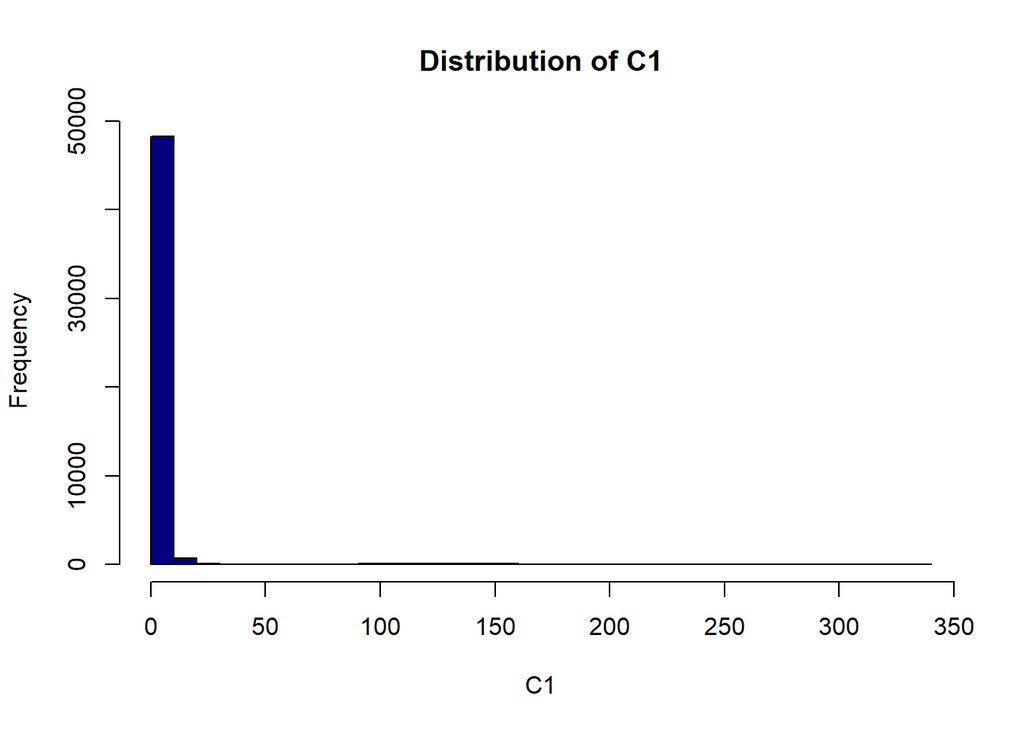

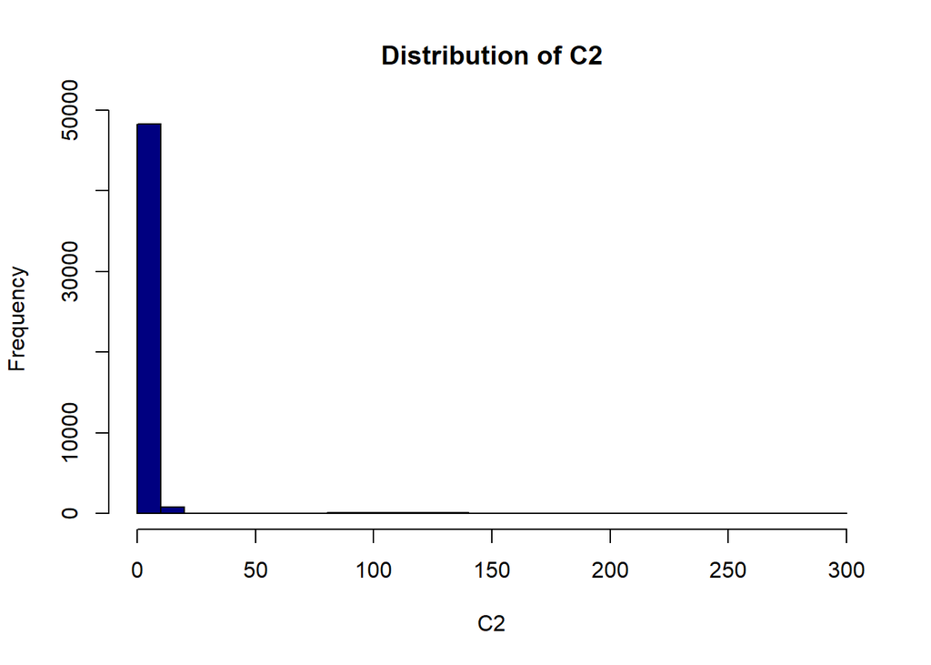

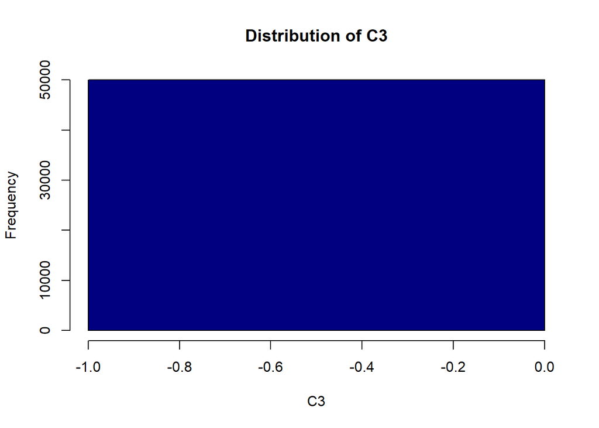

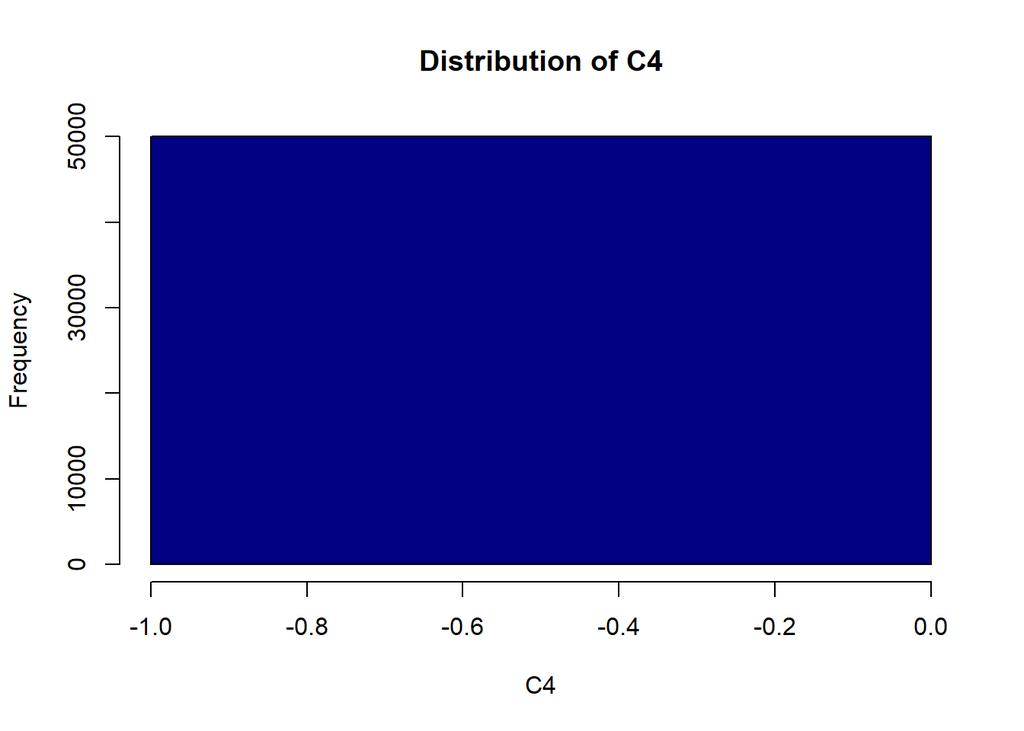

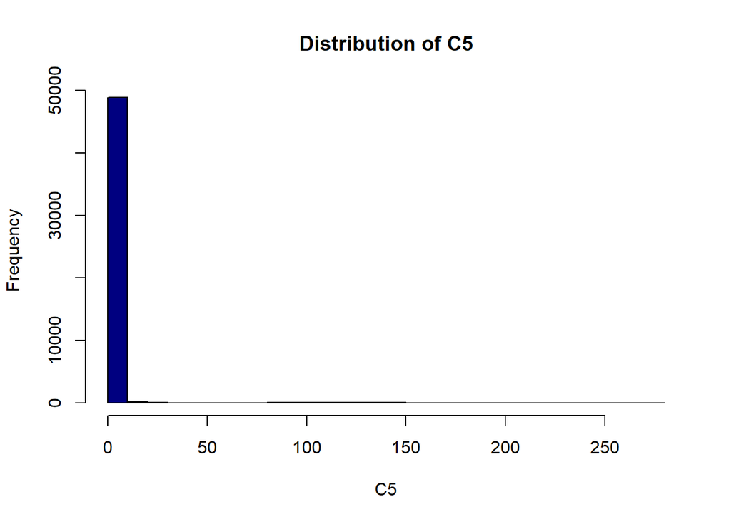

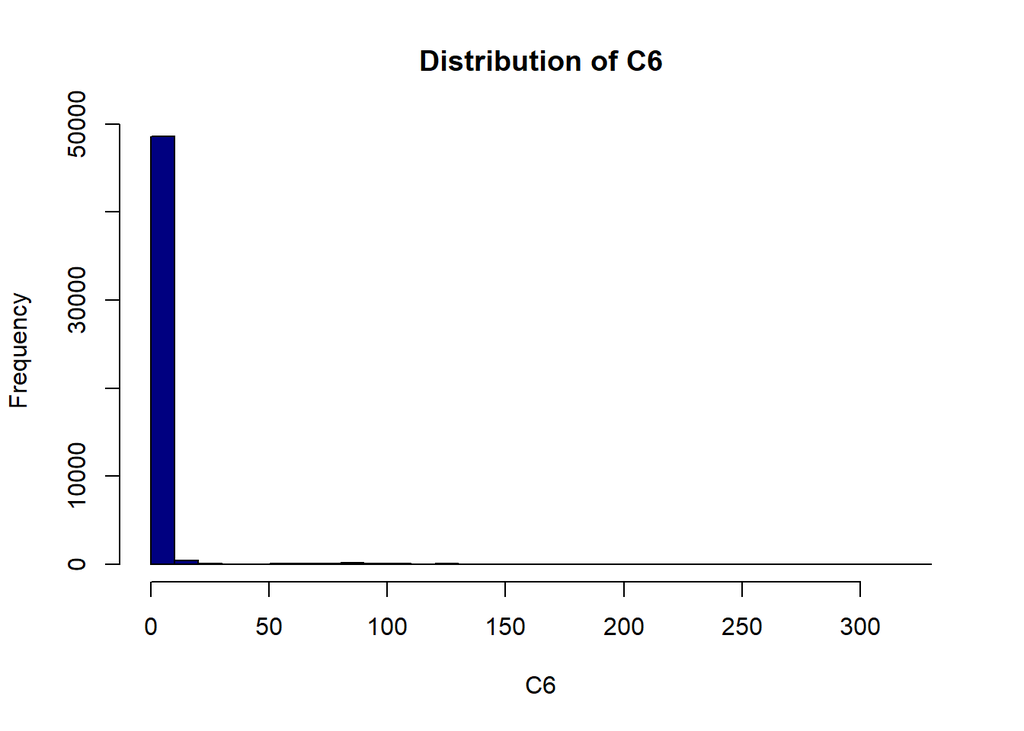

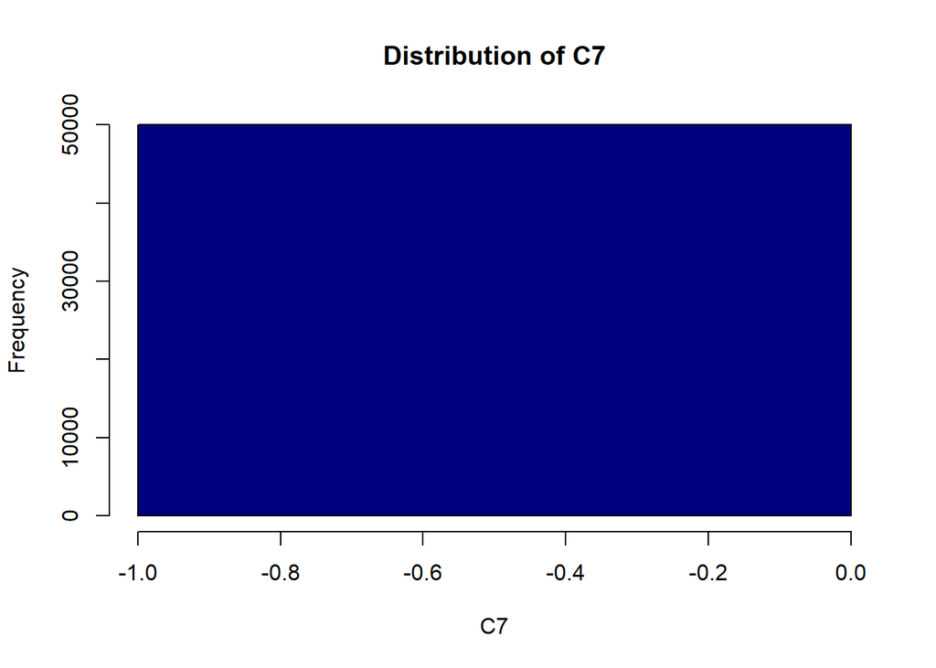

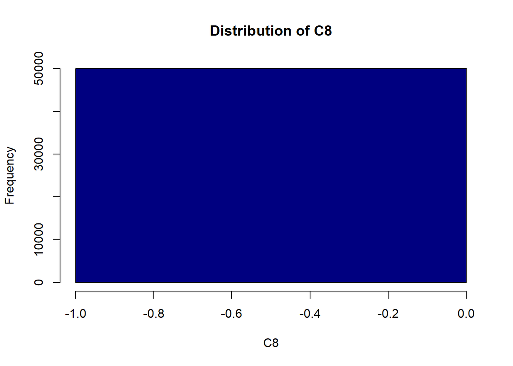

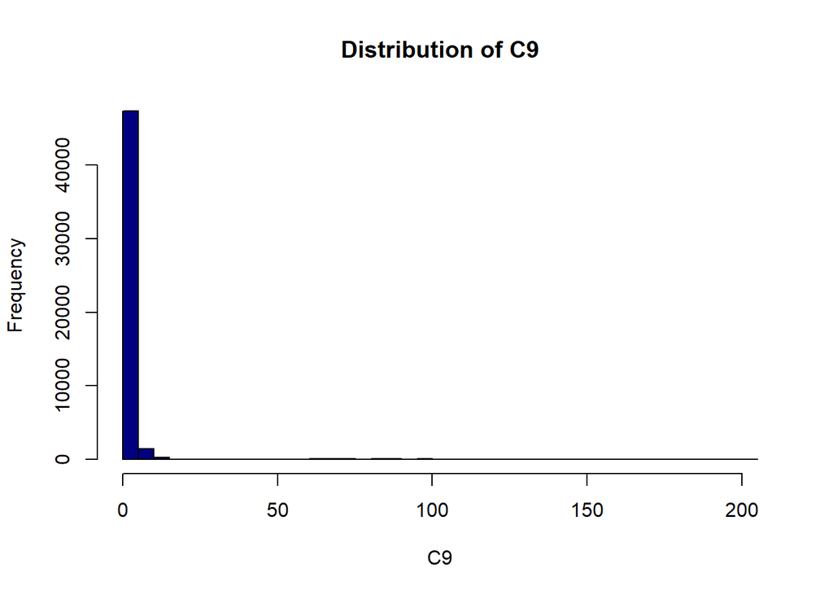

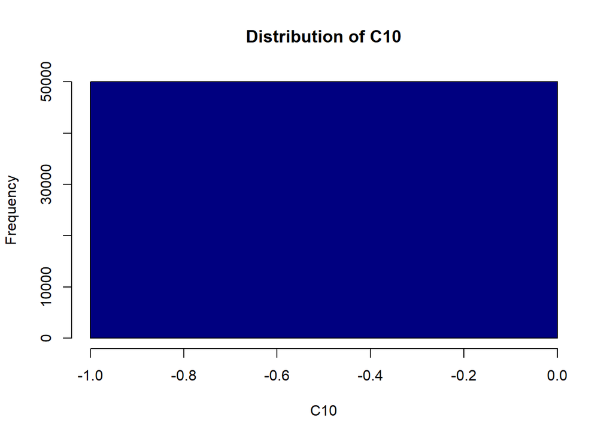

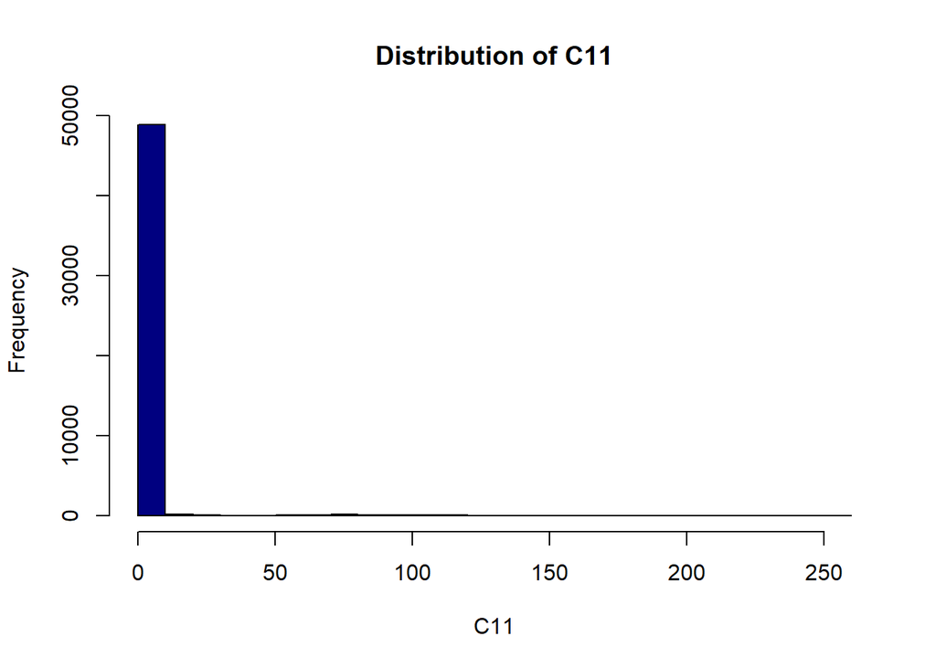

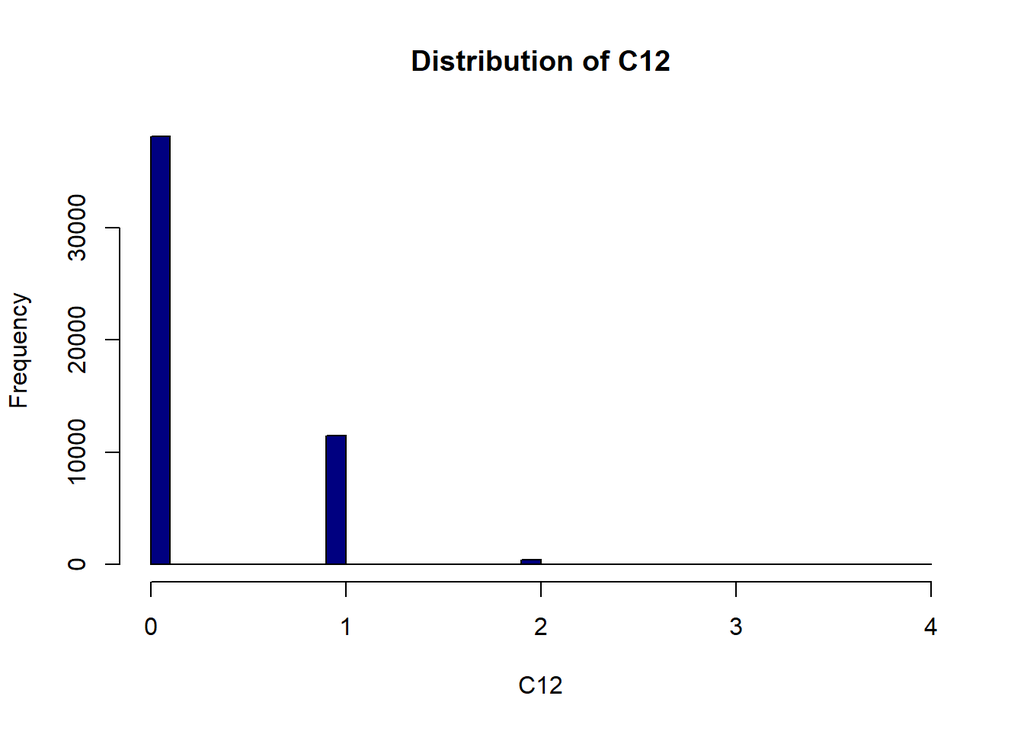

[2 more figures not shown]

```r
# Histograms for C1 to C14
for (i in 1:14) {
  col_name <- paste0("C", i) # Generate column name
  hist(new_fraud[[col_name]],
       main=paste("Distribution of", col_name),
       xlab=col_name,
       col="navy",
       breaks=30)
}
```

# **-Categorical variables analysis**

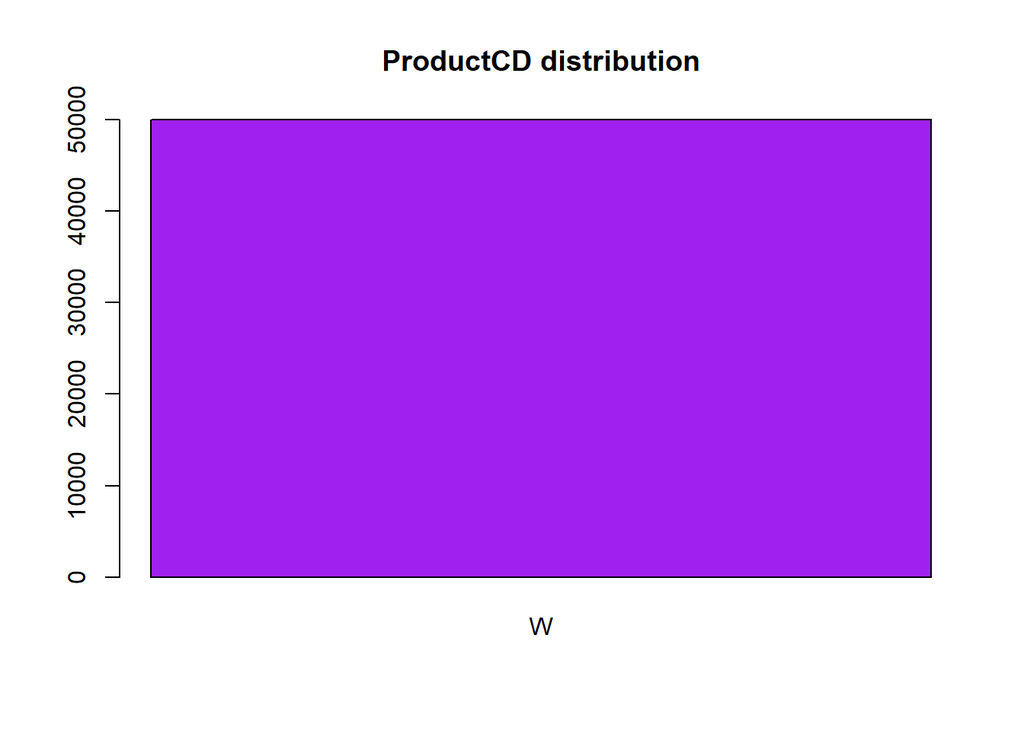

```r
# ProductCD
product_cd_counts <- table(new_fraud$ProductCD)
barplot(product_cd_counts, main="ProductCD distribution", col="purple")
```

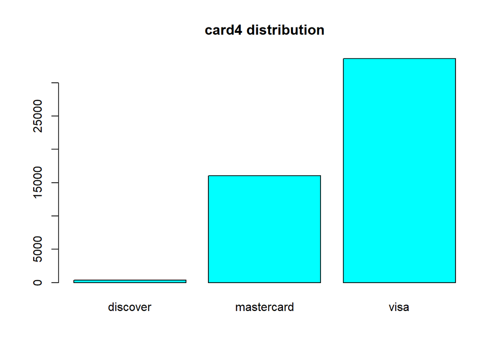

```r
# card4
card4_counts <- table(new_fraud$card4)
barplot(card4_counts, main="card4 distribution", col="cyan")
```

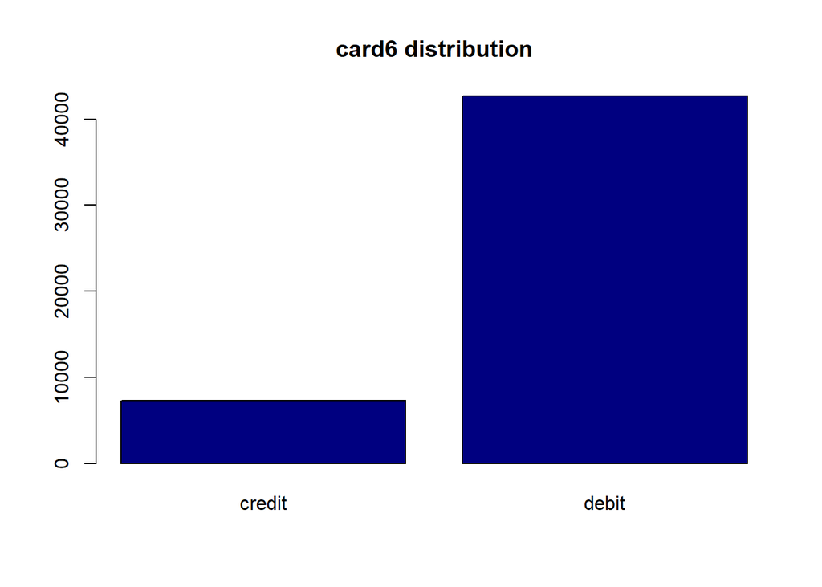

```r
# card6
card6_counts <- table(new_fraud$card6)
barplot(card6_counts, main="card6 distribution", col="navy")
```

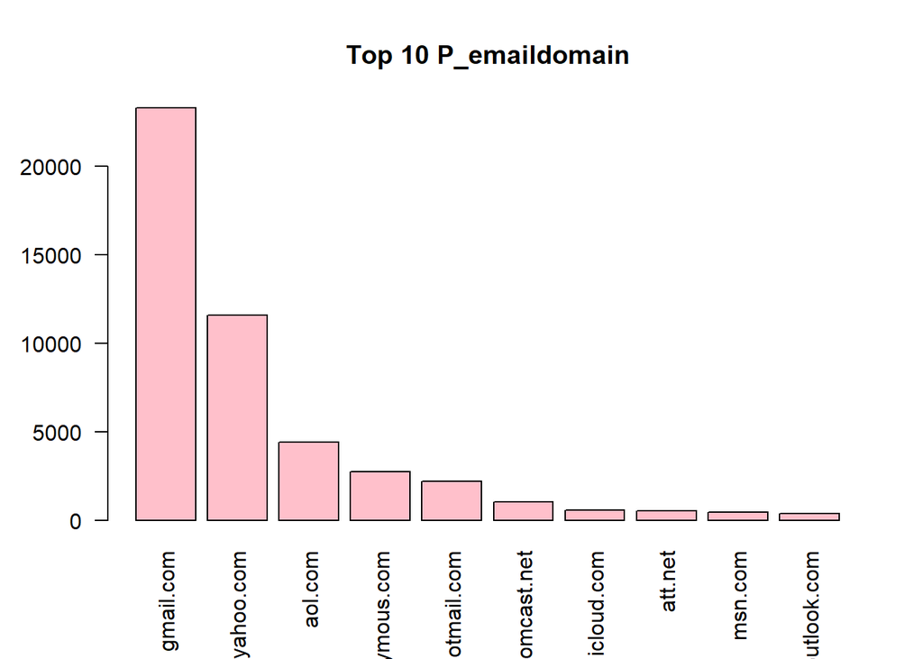

```r
# P_emaildomain
email_counts <- table(new_fraud$P_emaildomain)
top_emails <- sort(email_counts, decreasing = TRUE)[1:10] # Prime 10 email
barplot(top_emails, las=2, main="Top 10 P_emaildomain", col="pink")
```

**Observations:**

**1. ProductCD Distribution:**

- The variable **ProductCD** is dominated by a **single category (‘W’)**, covering the **entire dataset**.
- This lack of diversity may make it **less informative** for distinguishing fraudulent transactions.

**2. card4 Distribution:**

- The majority of transactions are associated with **Visa** and **Mastercard**, while **Discover** is **rare**.
- Fraud detection models might focus more on **rare categories** like **Discover** due to their **lower frequency**.

**3. card6 Distribution:**

- The majority of transactions are associated with **debit cards**, while **credit cards** represent a smaller share.
- The **imbalance** between debit and credit cards may indicate **different usage patterns**, which could be **relevant for fraud detection**.

**4. P_emaildomain Distribution:**

- The **Top 10 email domains** highlight that most transactions use **gmail.com** followed by **yahoo.com** and **aol.com**.
- **Rare domains** could indicate **potential fraud attempts** and require **special handling** in the model.